# Computer Science 1

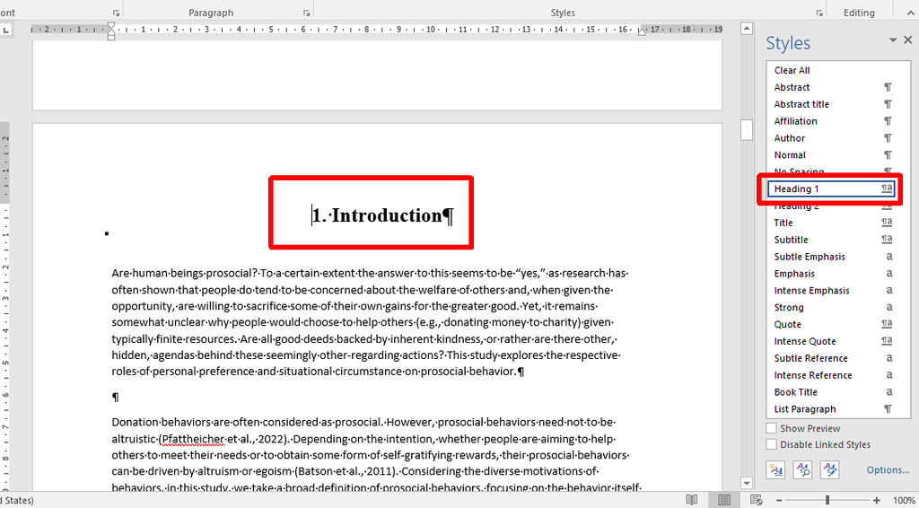

Apply the ‘Heading 1’ style

Apply the ‘Heading 1’ style to all titles, these are:

```
- 1. Introduction
- 2. Materials and methods
```

26. Create a new style ‘My text’ and apply it to the corresponding text. Features of the new style:
    - Font type: Times New Roman
    - Font style: Regular
    - Font size: 12 pt
    - Text alignment: Justified
    - Paragraph Spacing, Before: 0 pt
    - Paragraph Spacing, After: 3 pt
    - Paragraph Spacing, Line Spacing: 1.5 lines

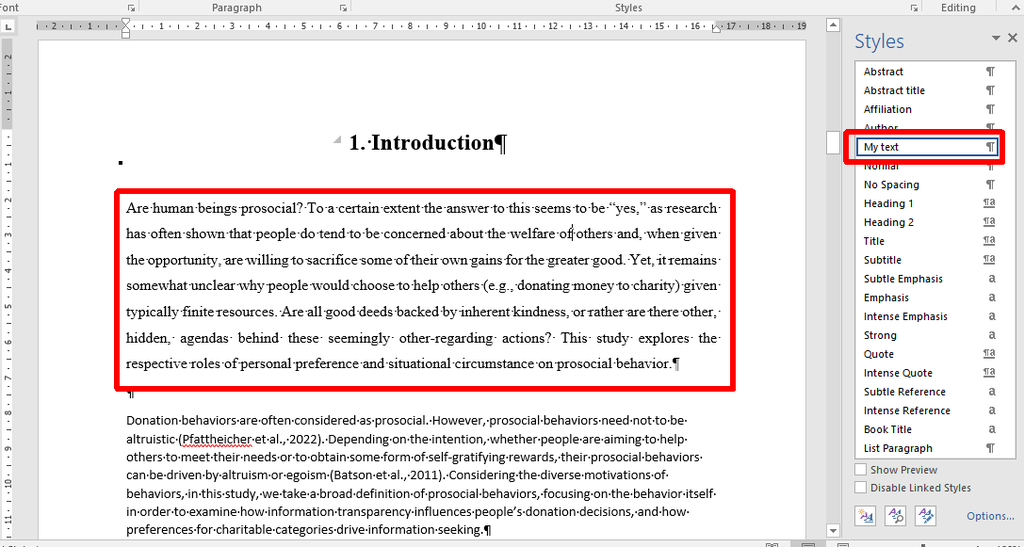

Apply the ‘My text’ style

Apply to all additional paragraphs except the titles:

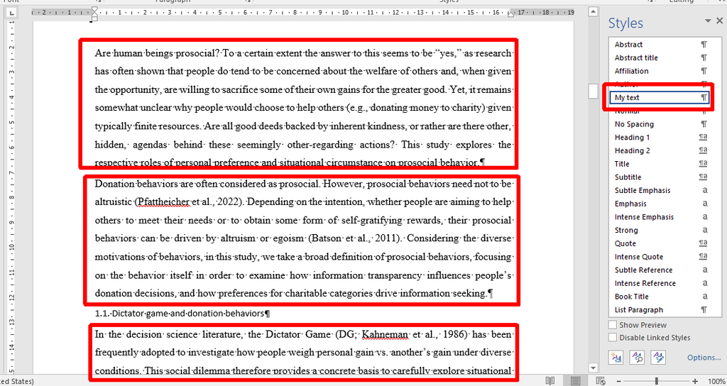

Apply the ‘My text’ style again

27. Modify the style ‘Header 2’ and apply it to the corresponding text. Features of the style ‘Heading 2’:
    - Font type: Times New Roman
    - Font style: Bold
    - Font size: 14 pt
    - Font color: Automatic
    - Text alignment: Left
    - Paragraph Spacing, Before: 24 pt
    - Paragraph Spacing, After: 18 pt
    - Paragraph Spacing, Line Spacing: 1.5 lines

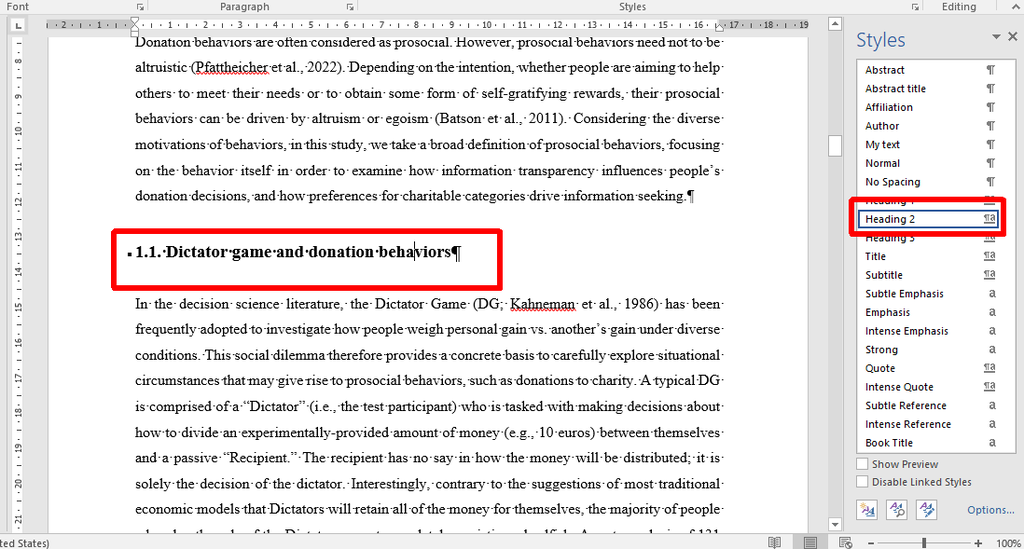

Apply the ‘Heading 2’ style

28. Modify the style ‘Header 3’ and apply it to the corresponding text. Features of the style ‘Heading 3’:

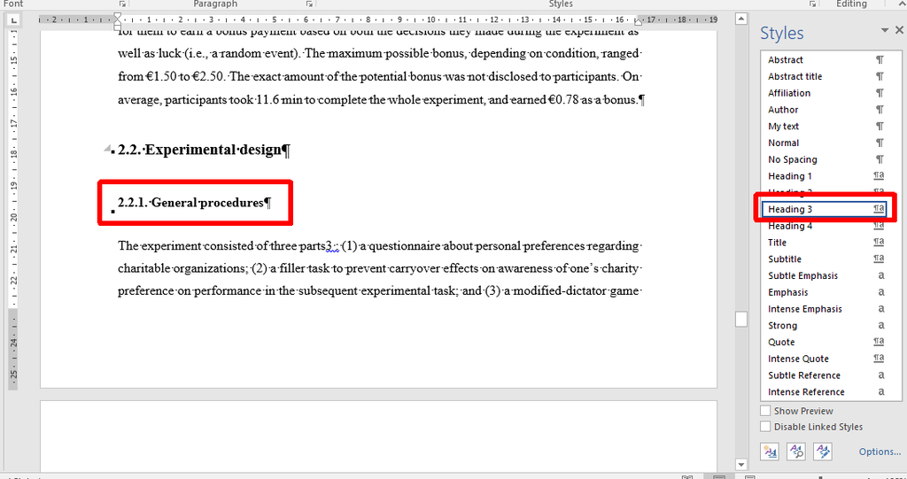

Apply the ‘Heading 3’ style

```
- Font type: Times New Roman
- Font style: Bold
- Font size: 12 pt
- Font color: Automatic
- Text alignment: Left
- Paragraph Spacing, Before: 24 pt
- Paragraph Spacing, After: 18 pt
- Paragraph Spacing, Line Spacing: 1.5 lines
```

29. Insert a table with 12 rows and 5 columns before ‘Figure 1’. Details [here](https://support.microsoft.com/en-us/office/video-insert-a-table-9bc4b562-4f88-4ba0-9a59-4b29cfa0bb29).

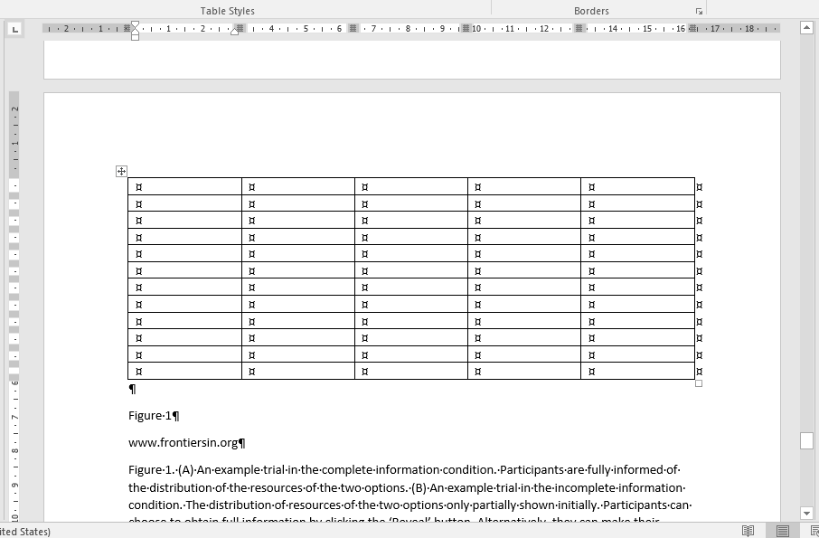

Insert a table 12x5

30. Fill the cells with content.

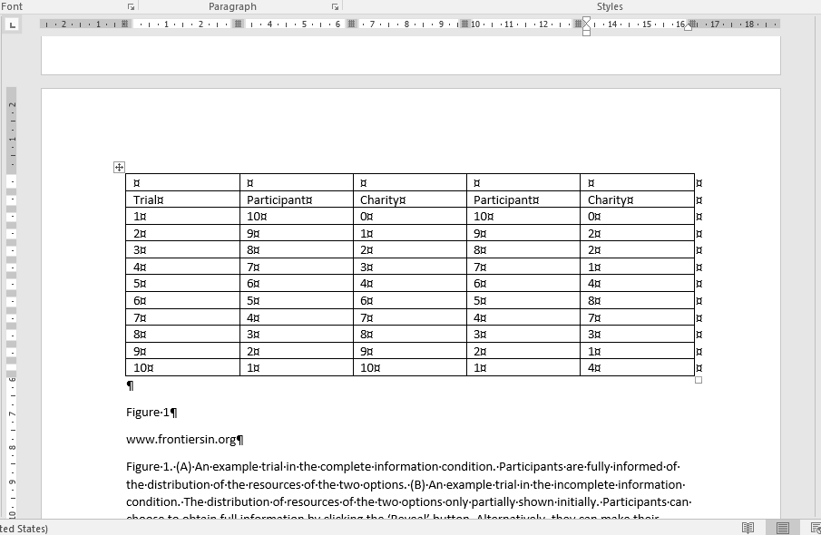

Fill the table

31. Merge cells in the table. Details [here](https://support.microsoft.com/en-us/office/video-merge-and-split-table-cells-in-word-3e42e8d8-89e8-4345-a79c-524a815f40ce).

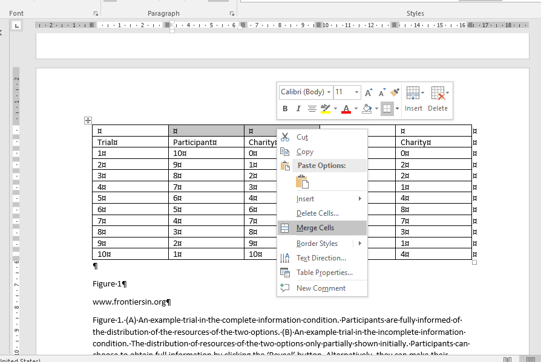

Merge cells in the table

32. Fill the merged cells with content.

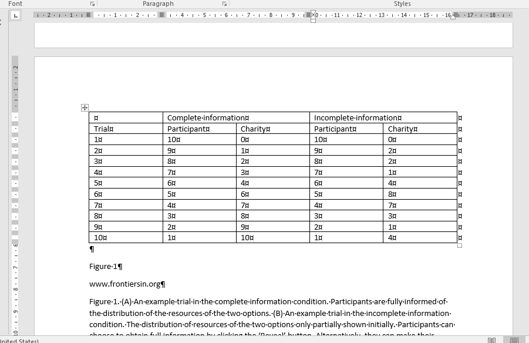

Fill merged cells

33. Select the whole table. Details [here](https://www.howtogeek.com/221131/how-to-select-all-or-part-of-a-table-in-word/).

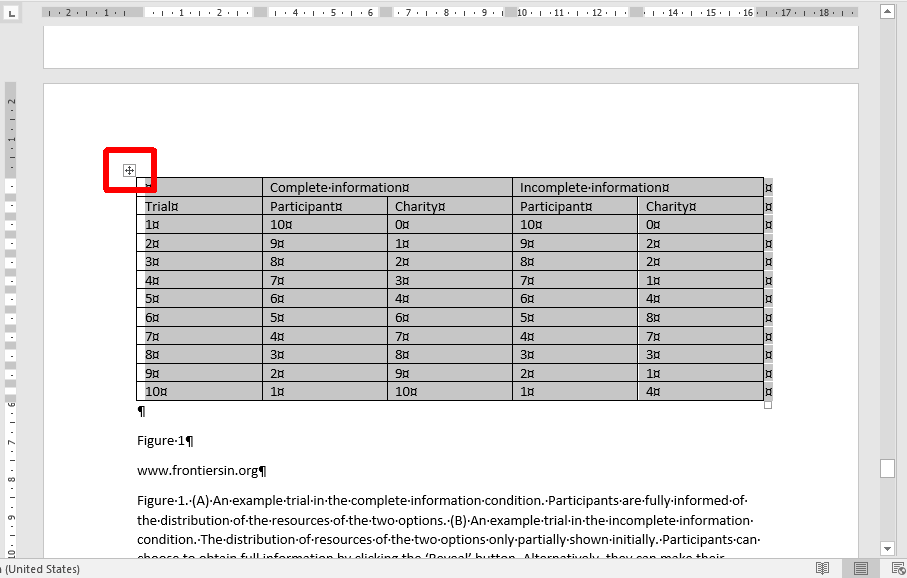

Select the table

34. Select font ‘Times New Roman’ and size 12 pt.

[figure not shown]

Setting fonts

35. Select cells and align them to the centre.

[figure not shown]

Centered cells

36. Select cells and format them in bold.

[figure not shown]

Bold headers

37. Adjust column width automatically, click AutoFit Contents. Details [here](https://support.microsoft.com/en-us/office/resize-a-table-column-or-row-9340d478-21be-4392-81cf-488f7bbd6715).

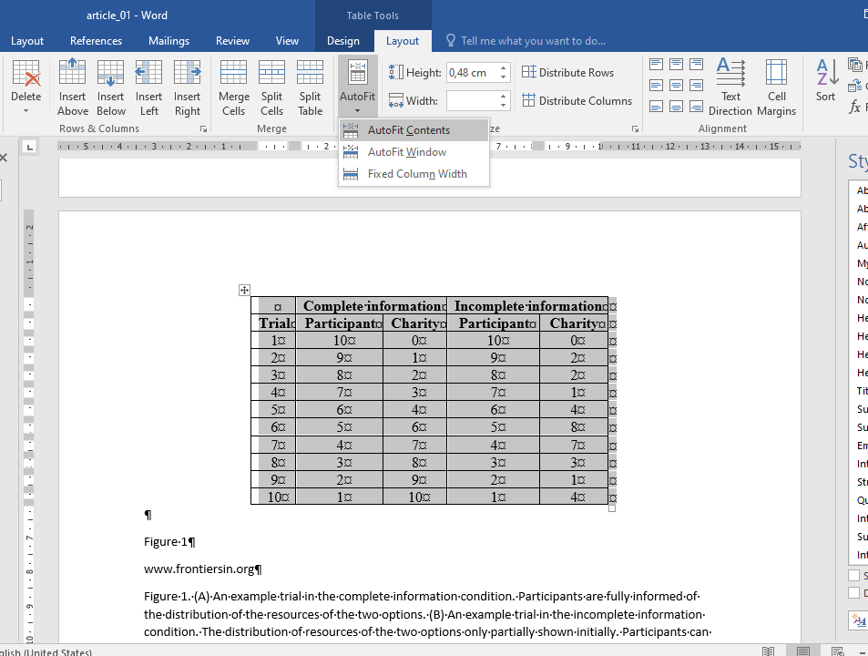

Autofit Content

38. Align the table to the left.

[figure not shown]

Left align table

39. Delete the borders of the table.

[figure not shown]

No border

40. Set the border at the top and bottom of the table.

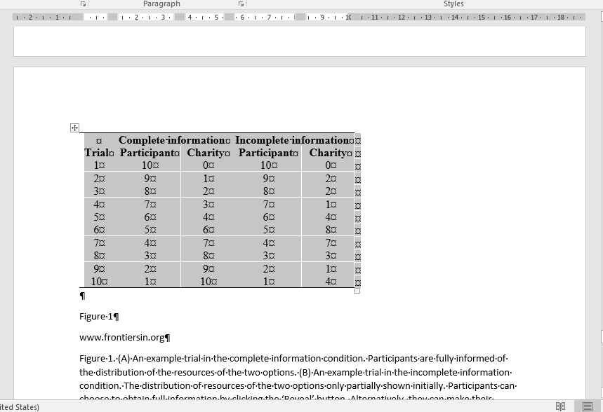

Top and bottom border

41. Select the second header row.

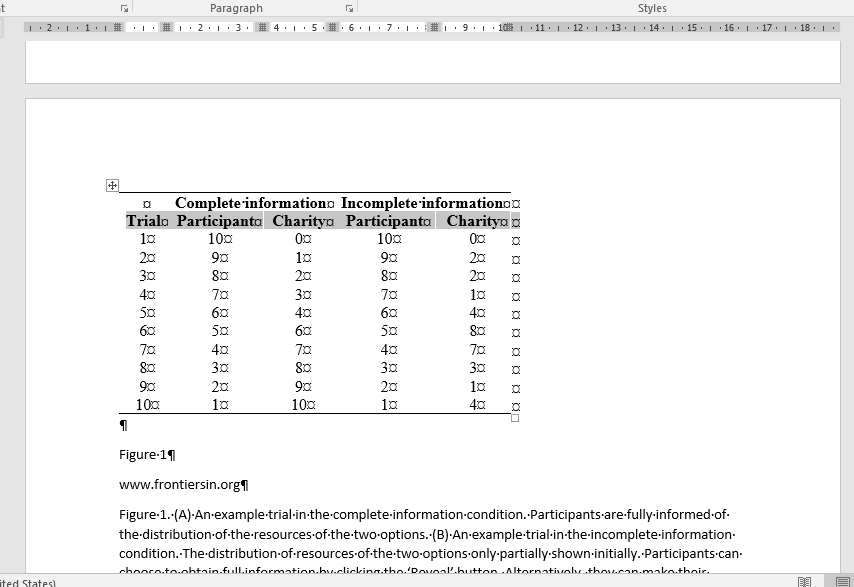

Select a row

42. Set the border at the bottom of the row.

[figure not shown]

Bottom border

43. Create 3 new styles ‘Table and Figure number’, ‘Table and Figure title’, and ‘Table and Figure comment’. Apply it to the corresponding text. Features of the new styles:
    - Table and Figure number
      - Font type: Times New Roman
      - Font style: Bold
      - Font size: 12 pt
      - Font color: Automatic
      - Text alignment: Left
      - Paragraph Spacing, Before: 24 pt
      - Paragraph Spacing, After: 8 pt
      - Paragraph Spacing, Line Spacing: 1.5 lines
      - Line and Page Breaks: Keep with next
    - Table and Figure title
      - Font type: Times New Roman
      - Font style: Italic
      - Font size: 12 pt
      - Font color: Automatic
      - Text alignment: Left
      - Paragraph Spacing, Before: 0 pt
      - Paragraph Spacing, After: 12 pt
      - Paragraph Spacing, Line Spacing: 1.5 lines
    - Table and Figure comment
      - Font type: Times New Roman
      - Font style: Regular
      - Font size: 10 pt
      - Font color: Automatic
      - Text alignment: Justified
      - Paragraph Spacing, Before: 6 pt
      - Paragraph Spacing, After: 24 pt
      - Paragraph Spacing, Line Spacing: Single
44. Format the table as shown in the picture, using the 3 styles above.

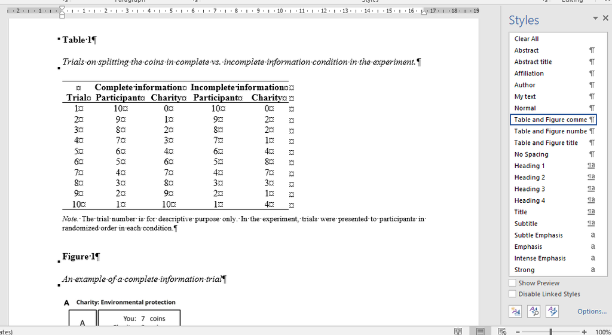

Titled and noted table

45. Format the image as shown in the picture, using the 3 styles above. [Insert the image](https://support.microsoft.com/en-us/office/insert-pictures-3c51edf4-22e1-460a-b372-9329a8724344) from the article and adjust the width to 9.85 cm.

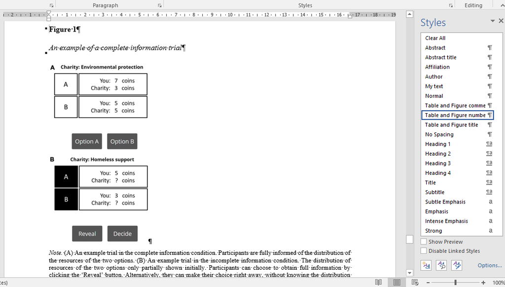

Titled and noted figure

46. Let’s create a BibTex file, named `article_01.bib`, from the first 5 cited articles. (See the Problem 1 and Problem 2 from the Lab 07.) These are:
    - Pfattheicher et al., 2022
      - doi: 10.1016/j.copsyc.2021.08.021
    - Batson et al., 2011
      - https://www.taylorfrancis.com/chapters/edit/10.4324/9780203833995-6/four-forms-prosocial-motivation-daniel-batson-nadia-ahmad-stocks
    - Kahneman et al., 1986
      - https://www.jstor.org/stable/2352761
    - Engel, 2011
      - https://doi.org/10.1007/s10683-011-9283-7
    - Cherry et al., 2002
      - DOI: 10.1257/00028280260344740

[figure not shown]

JabRef - `article_01.bib`

47. Save and Export your bib file as `article_01.xml` in ‘MS Office 2007’ format. Select `File / Export / Export all Entries`.

[figure not shown]

JabRef - Export `article_01.bib` as XML

48. Import `article_01.xml` into your Word document. Select `References / Manage sources / Browse` button. Copy all 5 items into Current List.

[figure not shown]

Import XML into Word

49. Replace text ‘(Pfattheicher et al., 2022)’ and ‘(Batson et al., 2011)’ in the chapter ‘1, Introduction’ with proper in-text citation. Select Insert Citation button from `References / Citations & References` pane.

[figure not shown]

Word - Insert citation

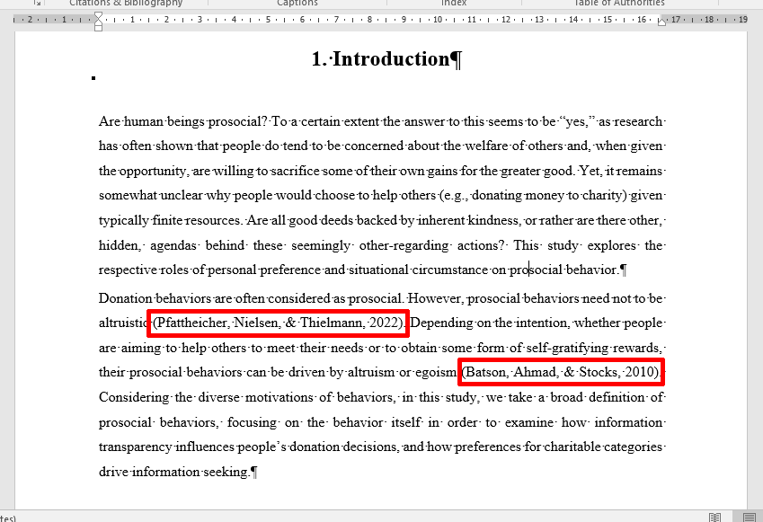

In-text citations

50. Replace text ‘(DG; Kahneman et al., 1986)’, ‘(Engel, 2011)’, and ‘(Cherry et al., 2002)’ in the chapter ‘1.1. Dictator game and donation behaviors’ with proper in-text citation. Select Insert Citation button from `References / Citations & References` pane.

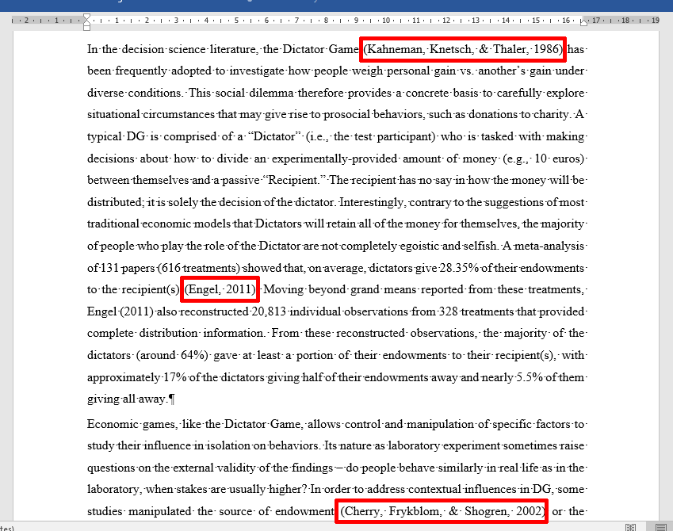

In-text citations

51. Insert the Bibliograpy at the end of the document.

[figure not shown]

Insert the Bibliography

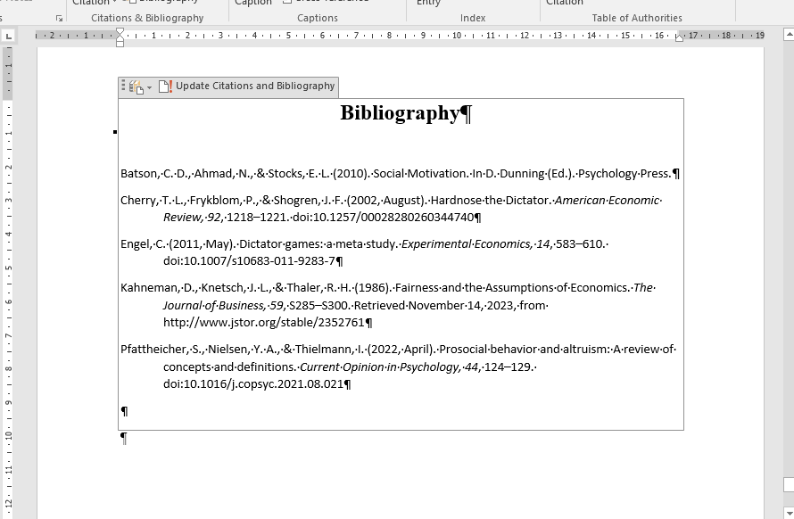

Geneterated Bibliography

52. Place the text cursor just before the title ‘1 Introduction’. Insert a Table of contents with `References / Table of Contents` button.

[figure not shown]

Insert the Table of Contents

53. Modify text ‘Contents’ to style ‘Heading 1’.

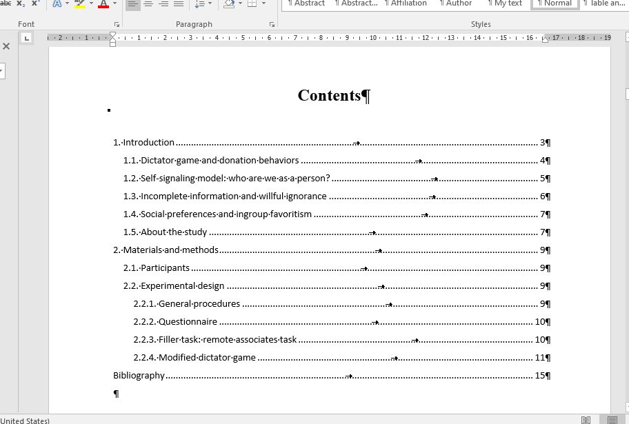

Format the text ‘Contents’

54. Place a Section Break after the Page break at the end of the abstract.

[figure not shown]

Insert a Section break

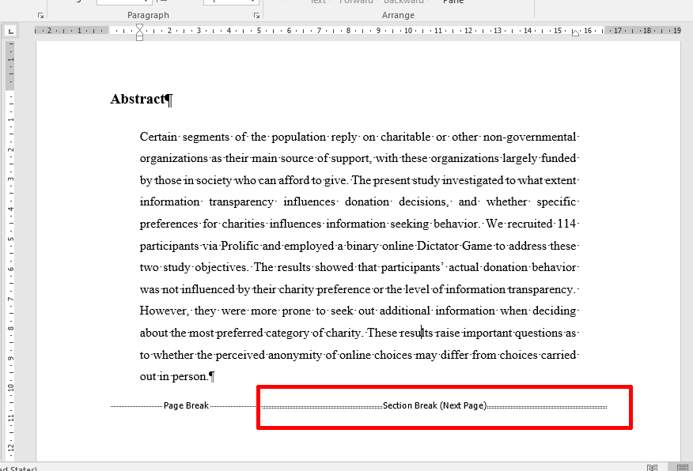

The new Section break

55. Double-click on page ‘Contets’ at the bottom of page. Turn off ‘Link to Previous’.

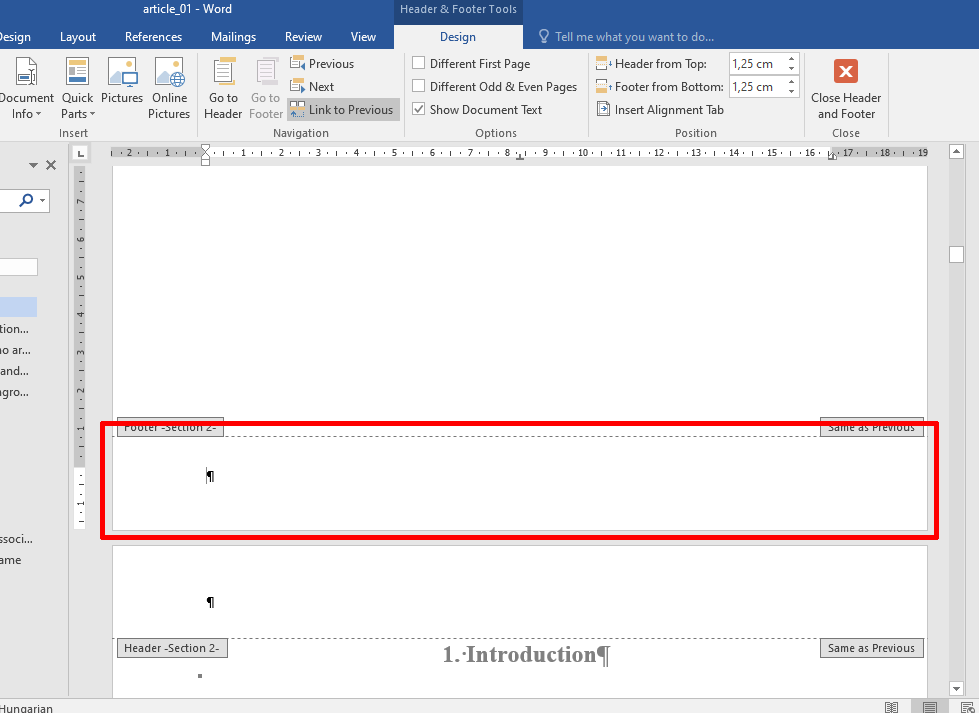

Enter the footer settings

56. Turn off ‘Link to Previous’ button.

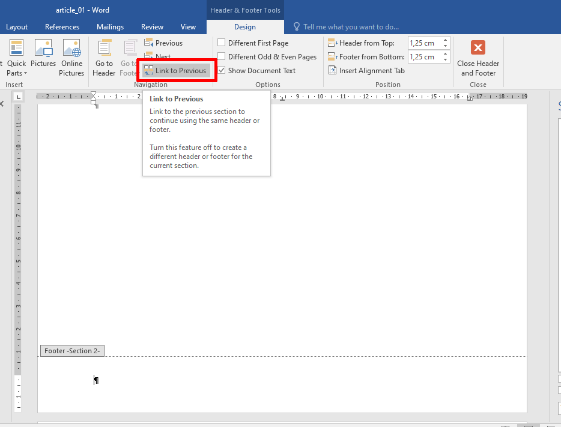

Turn off Link to Previous in Footer

57. Insert Page number at bottom of page.

[figure not shown]

Setting Page number

58. Set the Page numbering to start at 1.

[figure not shown]

Setting Page number format

59. Save and send your `article_01.docx` to the `abari.kurzus@gmail.com`. The subject of this email is `Lab10 - Problem 1`.

## Problem 2

> In this section, you will learn how to apply your word-processing skills to produce a complete, publication-ready scientific paper.
1. Prepare a Word version of the following freely available [article](https://www.frontiersin.org/articles/10.3389/fpsyg.2023.1175682/full). The full article should appear in the Word document:
   - title
   - authors
   - affiliations
   - abstract
   - 1-4 chapters
   - all images and tables
   - bibliography (it is sufficient to refer to the first 7 articles in the text and include these 7 articles in the automatically generated bibliography )
2. Save and send your `article_02.docx` to the `abari.kurzus@gmail.com`. The subject of this email is `Lab10 - Problem 2`.